# kommunrapport_master

[figure not shown]

Skinnskatteberg

Kommunrapport

Resultat från undersökningen  
Liv & hälsa ung 2026

Framtagen av ledningsstabens analysenhet vid Regionala utvecklingsförvaltningen, Region Västmanland

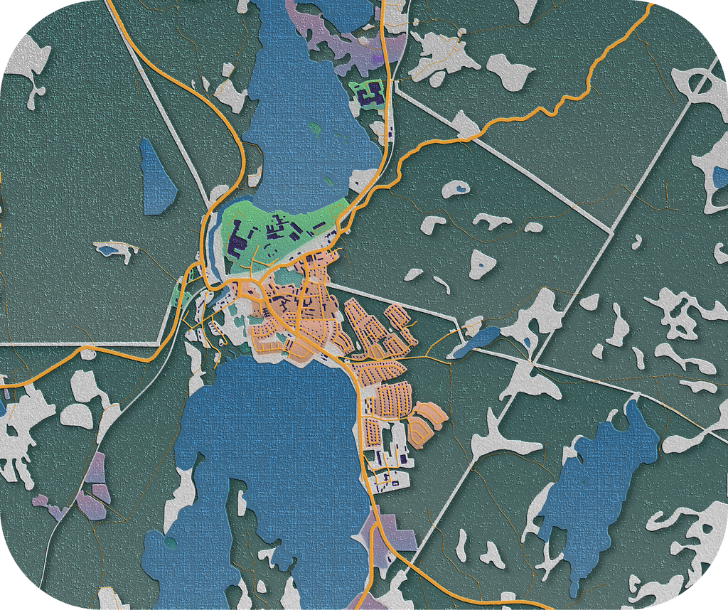

# Rapporten

Rapporten bygger på resultat från undersökningen *Liv & hälsa ung 2026*. Mer information om undersökningen finns i kapitlet **Om undersökningen**.

## Syfte

Syftet med rapporten är att ge Skinnskatteberg kommun en överskådlig bild av hur kommunens resultat från undersökningen Liv & hälsa ung förhåller sig till länssnittet inom olika områden. Rapporten är uppbyggd så att varje område först presenteras med ett sammanvägt indexvärde för området, följt av en nedbrytning i de enskilda indikatorer som indexet bygger på. På så sätt blir det möjligt att inte bara se det övergripande läget, utan också identifiera vad som driver resultatet och om det finns skillnader mellan killar och tjejer.

Rapporten kompletteras med en sambandsanalys som visar vilka områden och indikatorer som har störst betydelse för ungas mående. Sammantaget utgör rapporten ett underlag för att identifiera centrala utmaningar och prioritera insatser riktade till barn och unga i Skinnskatteberg .

## Metod

### Index

För beräkningen av delindexen används i första hand indikatorernas fullständiga svarsskalor, förutsatt att skalan enhetligt följer samma värderiktning. I de fall där den ursprungliga svarsskalan inte uppfyller detta krav, exempelvis där olika svarsalternativ representerar skilda situationer snarare än en graderad skala, används istället meningsfulla gruppindelningar som säkerställer en konsekvent värderiktning.

Varje indikator kodas om till skalan 0–10 och bidrar därefter med lika stor vikt till det delindex (område) den tillhör, oavsett hur många svarsalternativ eller grupper den ursprungligen består av. Delindexet beräknas som medelvärdet av de ingående indikatorerna och hamnar därmed alltid inom intervallet 0–10, vilket möjliggör jämförelser mellan områden.

Urvalet av indikatorer och konstruktionen av delindex har baserats på en kombination av statistiska analyser och konceptuella bedömningar. För varje delindex har vi undersökt om indikatorerna faktiskt mäter samma sak och hänger ihop med varandra på ett meningsfullt sätt, med hjälp av Cronbachs alfa (ett mått på intern konsistens) och principalkomponentanalys (PCA, en metod för att identifiera underliggande dimensioner i data). Indikatorer som visade sig mäta något i grunden annorlunda än övriga i ett index har prövats i andra index eller exkluderats. I de fall där ett område är brett och täcker flera delvis oberoende aspekter, som livsstil eller levnadsvillkor, har vi accepterat en lägre statistisk sammanhållning när indikatorerna ändå bedömts konceptuellt relevanta och viktiga för kommunernas beslutsunderlag.

### Områdenas innehåll

- **Utsatthet** – erfarenheter av diskriminering, trakasserier, utfrysning, hot, våld och rån.
- **Trygghet** – upplevd trygghet i bostadsområdet, skolan, på allmän plats och vid fritidsaktiviteter.
- **Tillit och förtroende** – tillit till andra människor samt förtroende för kommunen, polisen och skolan.
- **Studiegång och resultat** – skolresultat och skolfrånvaro, exempelvis underkända betyg och skolk.
- **Socialt stöd och ensamhet** – ensamhet, vänskapsrelationer och tillgång till någon att prata med och få stöd av.
- **Skolmiljö och stöd** – trivsel, studiero, stöd i skolarbetet samt relationen till och bemötandet från lärare.
- **Samhällssyn** – syn på människors lika rättigheter, våld och skadegörelse samt tillit till nyhetsmedier.
- **Livsstil** – skärmtid, sömn, matvanor, träning och fysisk aktivitet.
- **Levnadsvillkor** – familjens ekonomiska och materiella förutsättningar samt förutsättningar för studier i hemmet.
- **Hälsoförutsättningar och riskfaktorer** – stress, självskadebeteende, problematisk användning av digitala medier, sömnproblem och framtidstro.
- **Hälsa** – allmänt mående, psykiskt välbefinnande och psykisk påfrestning.
- **Föräldrarelation** – relationen till föräldrar, upplevt stöd och tillit samt föräldrarnas regler och gränssättning.
- **Fritid** – föreningsdeltagande, organiserade fritidsaktiviteter, möjlighet att delta och nöjdhet med fritiden.
- **Delaktighet** – olika former av samhälls- och politiskt deltagande, såsom diskussioner, kontakter med beslutsfattare och demonstrationer.
- **ANTS** – alkohol, narkotika, tobak och nikotin samt spel om pengar.

### Områdena i ett strukturellt sammanhang

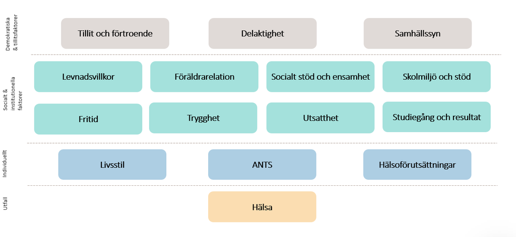

Bilden illustrerar en schematisk bild över hur rapportens områden förhåller sig till olika strukturella nivåer. Strukturen är inspirerad av Dahlgren och Whiteheads modell för hälsans bestämningsfaktorer (1991), men är anpassad utifrån de indikatorer och områden som faktiskt mäts i Liv och hälsa ung.

Modellen är ett analytiskt och pedagogiskt verktyg för att strukturera rapportens områden utifrån hur nära de ligger ungas vardag och hälsa. Den beskriver inte en exakt orsakskedja, i verkligheten samspelar områdena och många samband är ömsesidiga. Exempelvis kan hälsa påverka skolresultat, samtidigt som skolresultat kan påverka hälsa. Modellen belyser därför att olika områden kan påverkas genom insatser på olika nivåer och över olika långa tidsperspektiv.

Demokratiska och tillitsfaktorer utgör det yttersta lagret och inkluderar tillit och förtroende, delaktighet samt samhällssyn. Tillit och förtroende omfattar både mellanmänsklig tillit och förtroende för myndigheter och institutioner som skola, polis och kommun, faktorer som i stor usträckning formas av samhällsutvecklingen i stort. Delaktighet i samhällsfrågor påverkas förvisso av faktorer på lägre nivåer, som socialt stöd och individuella förutsättningar, men bedöms ändå tillhöra denna nivå eftersom graden av delaktighet också speglar hur samhällets strukturer möjliggör eller begränsar ungas inflytande. På liknande sätt påverkas samhällssynen, hur unga ser på frågor om mänskliga rättigheter, våld och medier, av normer och värderingar i det omgivande samhället.

Sociala och institutionella faktorer innefattar relationer och stöd från familj och vänner, men också faktorer kopplade till skolan som miljö, relationer och stöd från lärare. Hit hör även familjens socioekonomiska situation och de materiella levnadsvillkor den skapar, upplevd trygghet på olika platser samt erfarenheter av våld, hot och utsatthet. Fritid bedöms också vara en social och institutionell faktor, eftersom ungas möjligheter att delta i fritidsaktiviteter i hög grad formas av tillgång till arenor, ekonomiska förutsättningar och lokalt utbud, snarare än enbart individuella val. Hit hör även studiegång och resultat. Skolprestationer kan betraktas som ett utfall i sig då studieresultat följer samma sociala gradient som hälsa och påverkas i hög grad av samma underliggande faktorer. I den här rapporten är dock hälsa det primära utfallet, och studiegång och resultat behandlas därför som en av de faktorer som samvarierar med och kan bidra till att förklara ungas hälsa och välbefinnande. Placeringen motiveras också av det nära sambandet med skolmiljö och stöd.

Individuella faktorer innefattar livsstil, ANTS samt hälsoförutsättningar. Dessa faktorer speglar beteenden, vanor och riskfaktorer som i sin tur påverkas av de strukturella och sociala nivåerna ovanför.

Hälsa (allmänt månede) är utfallet för rapportens sambandsanalyser.

## Hur man läser rapporten

### Index

Delindexen visar kommunens sammanvägda resultat inom respektive område, baserat på de indikatorer som området består av. Indexvärdena rör sig mellan 0 och 10.

För samtliga områden gäller att ett högre indexvärde är mer önskvärt. Det innebär att ett högt värde på ANTS och Utsatthet speglar låg förekomst av ANTS-användning respektive låg grad av utsatthet, indikatorerna är inverterade innan indexberäkningen för att säkerställa en konsekvent värderiktning genom hela rapporten.

I den övergripande sammanfattningen av kommunens resultat används en gräns på ±0,2 indexenheter för att avgöra om ett område avviker meningsfullt från länssnittet. Gränsen baseras på den genomsnittliga variationen mellan kommuner i länet, där den typiska avvikelsen ligger på 0,10–0,20 indexenheter. Avvikelser under denna gräns bedöms som normal variation, medan avvikelser över 0,2 indexenheter lyfts fram som områden där kommunen sticker ut i förhållande till länet.

De områden och indikatorer som ingår i rapporten har valts ut för att vara så avgränsade och mätbara som möjligt, samtidigt som de tillsammans ger en tillräckligt bred bild av faktorer som är relevanta för ungas hälsa och välbefinnande. En grundläggande utgångspunkt i urvalet är att de flesta områden speglar förhållanden som går att påverka genom insatser från kommuner, skolor och andra aktörer som möter unga i vardagen.

Det är också viktigt att komma ihåg att områdena hänger ihop och kan påverka varandra. Möjligheten att påverka varierar. Inom vissa områden kan insatser ge resultat snabbare, medan andra förändras långsammare och kan påverkas mer av bredare samhällsfaktorer.

### Indikatorer

De enskilda indikatorerna presenteras som dikotomiserade andelar i resultatredovisningen, det vill säga andelen respondenter som tillhör en given grupp, exempelvis andelen som uppger god hälsa eller andelen som känner sig trygga. Detta görs för att underlätta läsbarheten och göra resultaten tillgängliga för en bred målgrupp. Till skillnad från indexvärdena redovisas enskilda indikatorer i frågans ursprungliga riktning. En hög andel kan därför innebära både en bättre situation, som hög andel trygga, och en sämre, som hög andel utsatta.

Det är värt att notera att dikotomiseringen enbart används i den deskriptiva resultatredovisningen. För beräkningen av delindexen används indikatorernas fullständiga svarsskalor eller gruppindelningar, i enlighet med vad som beskrivs ovan. En fullständig förteckning över samtliga frågor, ursprungliga svarsalternativ och hur de kodats i resultatredovisningen finns i Bilaga D – Variabellista.

### Diagram

I diagram i rapportens resultatredovisning gäller följande färgmarkeringar:

**För delindex:**

|  | Färg |
| --- | --- |
| Skinnskatteberg |  |
| Länssnittet |  |

**För indikatorer:**

|  | Skinnskatteberg | Län |
| --- | --- | --- |
| Kille |  |  |
| Tjej |  |  |
| Totalt |  |  |

# Att använda rapporten som underlag för prioritering

Rapporten ger underlag för prioritering på två sätt. Det första är kommunens egna resultat, på både områdes- och indikatornivå, som visar var unga i kommunen rapporterar mindre gynnsamt resultat än länssnittet. Det andra är sambandsanalysen, som visar vilka områden och indikatorer som har starkast samband med ungas allmänna mående i länet som helhet.

Med dessa två perspektiv kan kommunen identifiera områden där resultaten är sämre än länssnittet och där sambandet med mående samtidigt är starkt. Det ger ett kunskapsunderlag för att prioritera insatser inom områden som både framgår som utvecklingsområden i den egna kommunen och har starka samband med ungas mående.

Sambandsanalysen är densamma i samtliga kommunrapporter och utgör ett gemensamt analytiskt underlag, medan resultatdelen är specifik för varje kommun.

Jämförelsen med länssnittet är ett stöd för prioritering, men bör inte tolkas som ett mått på vad som är ett tillfredsställande resultat. På flera områden finns utvecklingsbehov även på länsnivå, vilket innebär att även resultat i nivå med eller över länssnittet kan motivera fortsatta insatser.

# Deltagande och svarsfrekvens

I Skinnskatteberg var det 77 elever som utgjorde elevantalet i deltagande skolor, med en svarsfrekvens på 90%. Eleverna i Skinnskatteberg utgör 1% av det totala urvalet i länet.

# Övergripande resultat

## Kommunindex

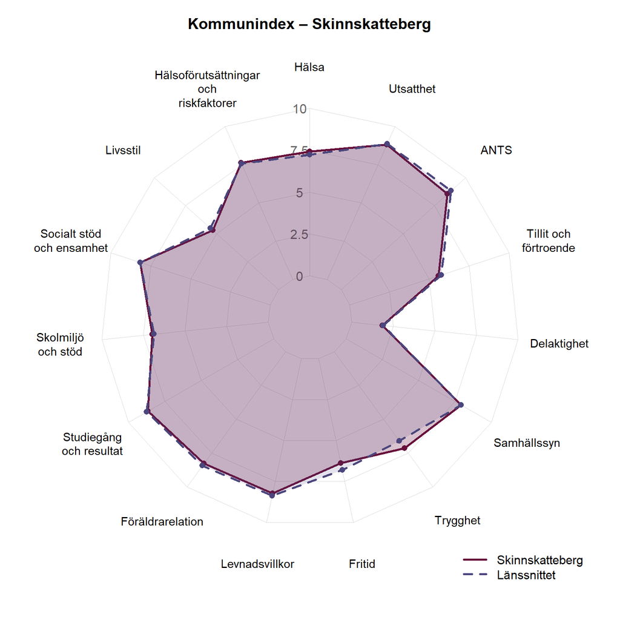

Diagram 1. Indexvärden per område jämfört med länssnittet.

Tabell 1. Kommunens indexvärden per område jämfört med länssnittet, sorterat efter avvikelse.

| Område | Kommunvärde | Länssnittet | Avvikelse |
| --- | --- | --- | --- |
| Trygghet | 7.12 | 6.59 | 0.53 |
| Fritid | 6.37 | 6.79 | -0.42 |
| ANTS | 8.54 | 8.84 | -0.30 |
| Hälsa | 7.42 | 7.22 | 0.20 |
| Livsstil | 5.30 | 5.49 | -0.19 |
| Tillit och förtroende | 5.57 | 5.74 | -0.17 |
| Föräldrarelation | 8.26 | 8.41 | -0.15 |
| Levnadsvillkor | 8.23 | 8.37 | -0.14 |
| Skolmiljö och stöd | 6.97 | 6.88 | 0.09 |
| Studiegång och resultat | 8.67 | 8.75 | -0.08 |
| Hälsoförutsättningar och riskfaktorer | 7.63 | 7.56 | 0.07 |
| Utsatthet | 8.81 | 8.87 | -0.06 |
| Delaktighet | 1.86 | 1.90 | -0.04 |
| Socialt stöd och ensamhet | 8.16 | 8.17 | -0.01 |
| Samhällssyn | 7.92 | 7.93 | -0.01 |

För Skinnskatteberg framgår ett mer gynnsamt resultat än länsgenomsnittet på områdena Trygghet, Hälsa. Det innebär att det sammanvägda indexvärdet för dessa områden överstiger länssnittet, vilket speglar att en större andel av unga i kommunen uppvisar positiva utfall på de indikatorer som bygger upp respektive område.

För Skinnskatteberg framgår ett mindre gynnsamt resultat än länsgenomsnittet på områdena Fritid, ANTS. Det innebär att det inom dessa områden finns ett relativt sett större behov av insatser riktade till unga i Skinnskatteberg.

För Skinnskatteberg ligger områdena Hälsoförutsättningar och riskfaktorer, Livsstil, Socialt stöd och ensamhet, Föräldrarelation, Levnadsvillkor, Utsatthet, Samhällssyn, Delaktighet, Tillit och förtroende, Skolmiljö och stöd, Studiegång och resultat nära länssnittet, vilket tyder på att kommunen i stora drag följer det länsövergripande mönstret inom dessa områden.

# Resultat per område

Under respektive område redovisas dels ett sammanvägt indexvärde, dels resultaten för de enskilda indikatorerna som indexet bygger på. Indexvärdet ger en övergripande bild av läget inom området, medan indikatorerna visar vad som driver resultatet och om det finns skillnader mellan killar och tjejer.

## Hälsa

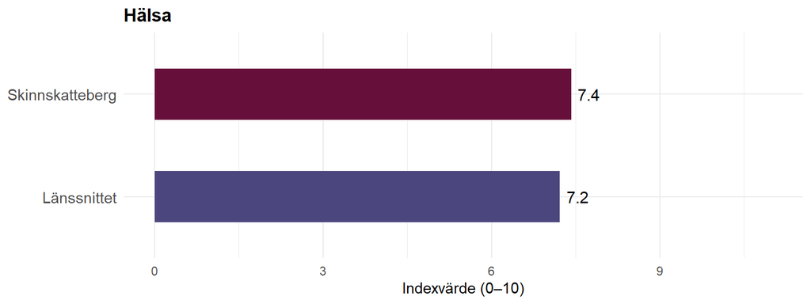

Diagram 2. Indexvärde för Hälsa jämfört med länssnittet.

Resultatet för Skinnskatteberg visar en mer gynnsam nivå på området Hälsa jämfört med länsgenomsnittet (7.4 jämfört med 7.2), vilket tyder på att kommunen överlag har mer gynnsamma utfall för de indikatorer som ingår i området.

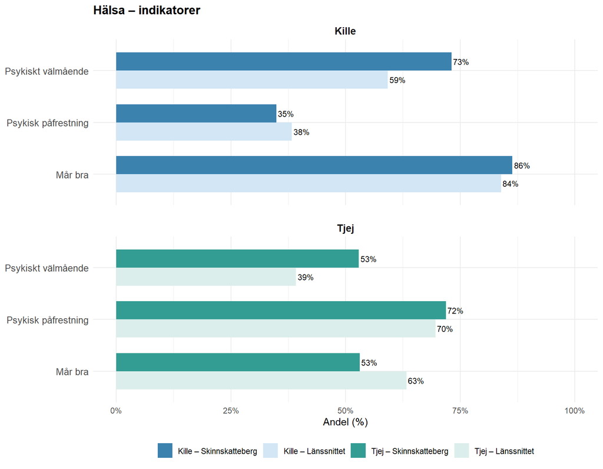

Diagram 3. Indikatorer inom Hälsa - andel per kön jämfört med länssnittet

Tabell 2. Indikatorer inom Hälsa – kommunens värde jämfört med länssnittet.

| Indikator | Kommun (%) | Länssnittet (%) | ± % | Jämfört med länet |
| --- | --- | --- | --- | --- |
| Psykiskt välmående | 65 | 49 | 16 | ▲ Högre |
| Psykisk påfrestning | 51 | 54 | -3 | ▼ Lägre |
| Mår bra | 72 | 74 | -1 | ▼ Lägre |

Det högre resultatet för området Hälsa beror främst på att andelen som uppger gott psykiskt välmående är 16 procentenheter högre än i länets genomsnitt. Skillnaden finns bland både tjejer och killar, med 14 procentenheter högre andel än i länet för respektive kön. Samtidigt är andelen tjejer som mår bra 10 procentenheter lägre än bland tjejer i länet. Bland killar ligger psykisk påfrestning och andelen som mår bra nära länets nivå.

## Utsatthet

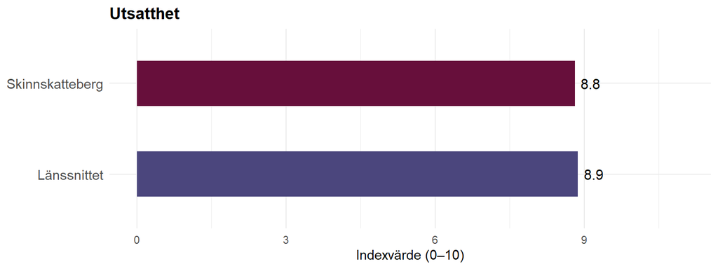

Diagram 4. Indexvärde för Utsatthet jämfört med länssnittet.

Resultatet för Skinnskatteberg visar en nivå i linje med länsgenomsnittet på området Utsatthet (8.8 jämfört med 8.9), vilket innebär att kommunen följer det övergripande mönstret i länet.

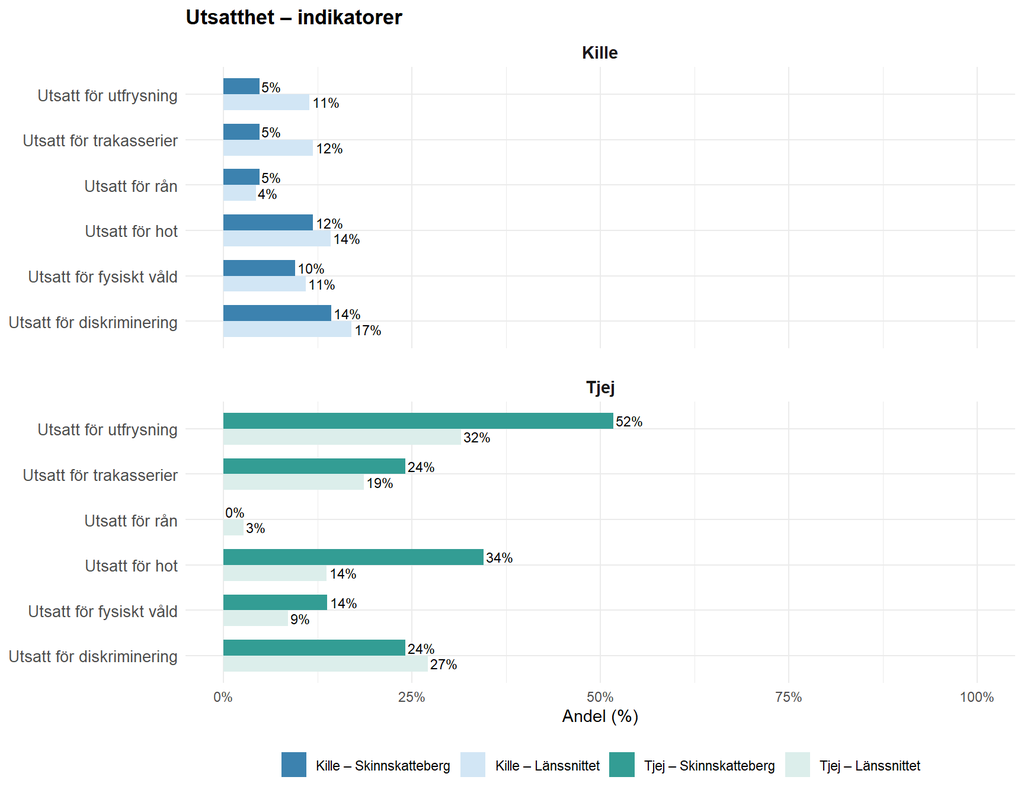

Diagram 5. Indikatorer inom Utsatthet - andel per kön jämfört med länssnittet

Tabell 3. Indikatorer inom Utsatthet – kommunens värde jämfört med länssnittet.

| Indikator | Kommun (%) | Länssnittet (%) | ± % | Jämfört med länet |
| --- | --- | --- | --- | --- |
| Utsatt för hot | 21 | 14 | 7 | ▲ Högre |
| Utsatt för diskriminering | 18 | 22 | -4 | ▼ Lägre |
| Utsatt för trakasserier | 13 | 15 | -3 | ▼ Lägre |
| Utsatt för utfrysning | 24 | 22 | 2 | ▲ Högre |
| Utsatt för fysiskt våld | 11 | 10 | 2 | ▲ Högre |
| Utsatt för rån | 3 | 3 | -1 | ▼ Lägre |

Skinnskattebergs samlade resultat för området Utsatthet ligger nära länets nivå, men resultaten skiljer sig mellan tjejer och killar. Bland tjejer är andelen som utsatts för utfrysning och för hot 20 procentenheter högre än bland tjejer i länet. Relativt sett är andelen som utsatts för hot mer än dubbelt så hög. Även trakasserier och fysiskt våld är något vanligare bland tjejer än i länet. Bland killar är andelen som utsatts för utfrysning och trakasserier i stället 6–7 procentenheter lägre än i länet. Skillnaderna mellan tjejer och killar är därmed större i Skinnskatteberg än i länet.

## ANTS

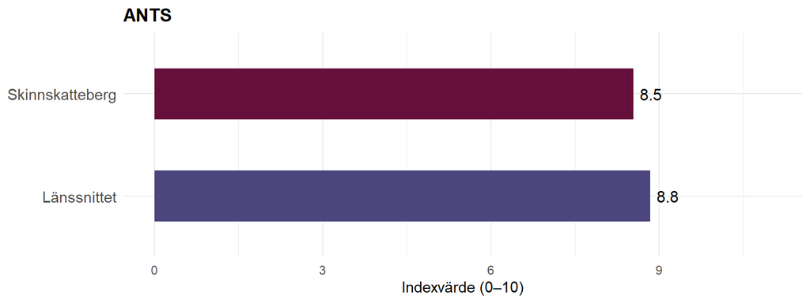

Diagram 6. Indexvärde för ANTS jämfört med länssnittet.

Resultatet för Skinnskatteberg visar en mindre gynnsam nivå på området ANTS jämfört med länsgenomsnittet (8.5 jämfört med 8.8), vilket tyder på att kommunen överlag har mindre gynnsamma utfall för de indikatorer som ingår i området.

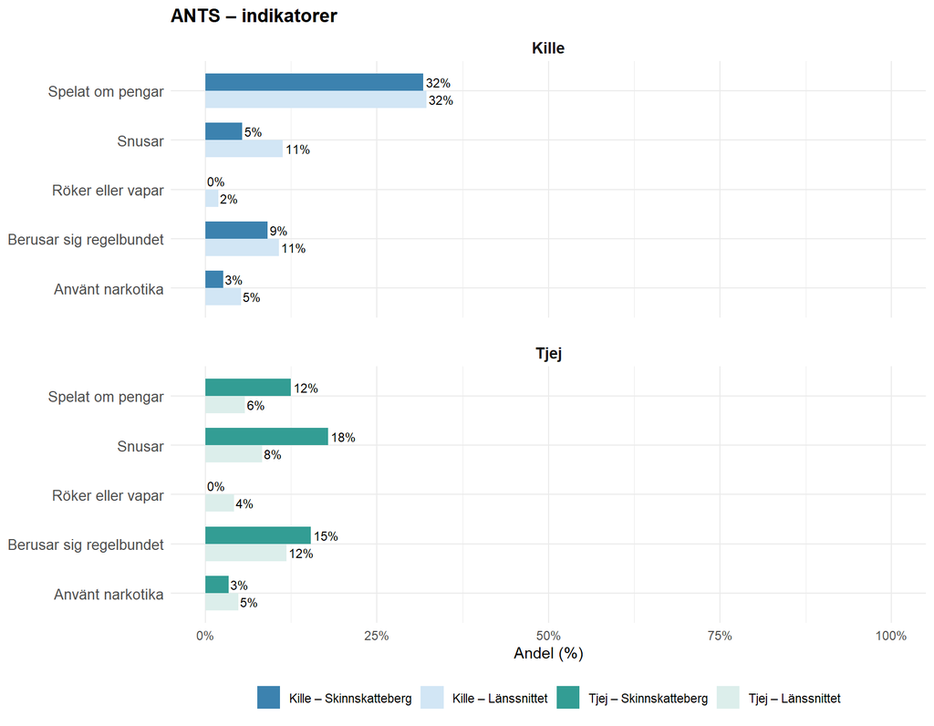

Diagram 7. Indikatorer inom ANTS - andel per kön jämfört med länssnittet

Tabell 4. Indikatorer inom ANTS – kommunens värde jämfört med länssnittet.

| Indikator | Kommun (%) | Länssnittet (%) | ± % | Jämfört med länet |
| --- | --- | --- | --- | --- |
| Spelat om pengar | 24 | 19 | 5 | ▲ Högre |
| Röker eller vapar | 0 | 3 | -3 | ▼ Lägre |
| Använt narkotika | 3 | 5 | -2 | ▼ Lägre |
| Snusar | 11 | 10 | 1 | ▲ Högre |
| Berusar sig regelbundet | 12 | 11 | 1 | ▲ Högre |

Det något lägre indexvärdet för ANTS-området beror främst på tjejernas resultat. Andelen tjejer som snusar är mer än dubbelt så hög som bland tjejer i länet, och andelen som spelat om pengar är dubbelt så hög. Bland killar är andelen som snusar i stället ungefär hälften så stor som i länet, medan övriga indikatorer ligger nära länets nivå. Ingen av de svarande tjejerna eller killarna uppger att de röker eller vapar.

## Tillit och förtroende

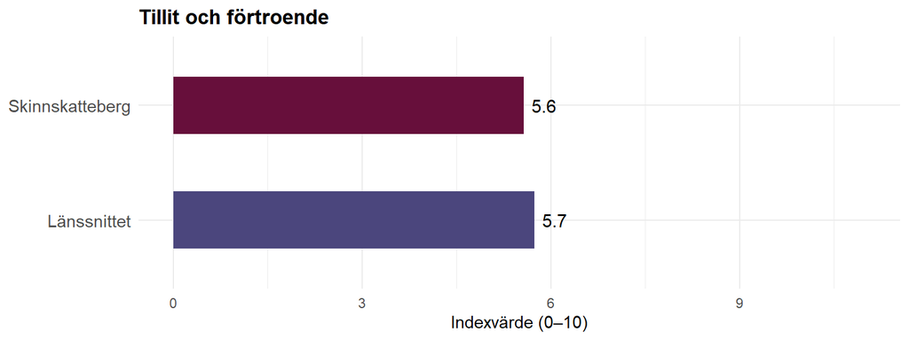

Diagram 8. Indexvärde för Tillit och förtroende jämfört med länssnittet.

Resultatet för Skinnskatteberg visar en nivå i linje med länsgenomsnittet på området Tillit och förtroende (5.6 jämfört med 5.7), vilket innebär att kommunen följer det övergripande mönstret i länet.

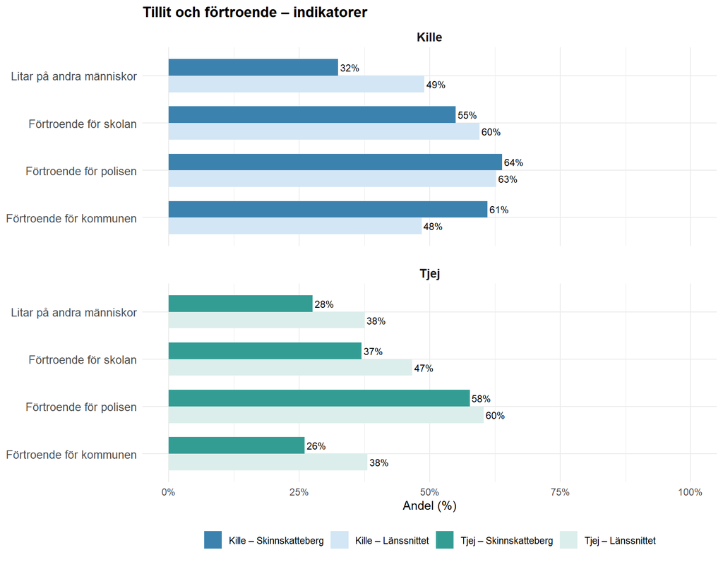

Diagram 9. Indikatorer inom Tillit och förtroende - andel per kön jämfört med länssnittet

Tabell 5. Indikatorer inom Tillit och förtroende – kommunens värde jämfört med länssnittet.

| Indikator | Kommun (%) | Länssnittet (%) | ± % | Jämfört med länet |
| --- | --- | --- | --- | --- |
| Litar på andra människor | 30 | 43 | -13 | ▼ Lägre |
| Förtroende för skolan | 48 | 53 | -5 | ▼ Lägre |
| Förtroende för kommunen | 48 | 43 | 4 | ▲ Högre |
| Förtroende för polisen | 61 | 62 | 0 | ▼ Lägre |

Skinnskattebergs samlade resultat för området Tillit och förtroende ligger nära länets nivå, men på indikatornivå går resultaten åt olika håll. Andelen som litar på andra människor är 13 procentenheter lägre än i länet, och skillnaden finns bland både tjejer och killar. Bland tjejer är också förtroendet för skolan och för kommunen 10–12 procentenheter lägre än i länet. Bland killar är förtroendet för kommunen i stället 13 procentenheter högre än i länet, vilket gör att skillnaden mellan tjejer och killar på den indikatorn är betydligt större i Skinnskatteberg än i länet. Förtroendet för polisen ligger i nivå med länet för båda könen.

## Delaktighet

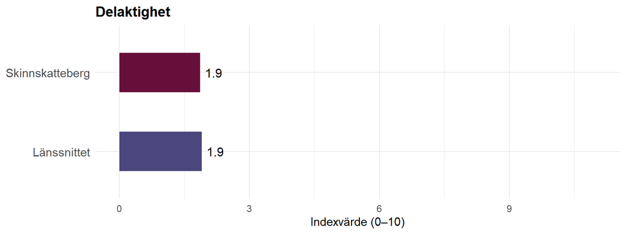

Diagram 10. Indexvärde för Delaktighet jämfört med länssnittet.

Resultatet för Skinnskatteberg visar en nivå i linje med länsgenomsnittet på området Delaktighet (1.9 jämfört med 1.9), vilket innebär att kommunen följer det övergripande mönstret i länet.

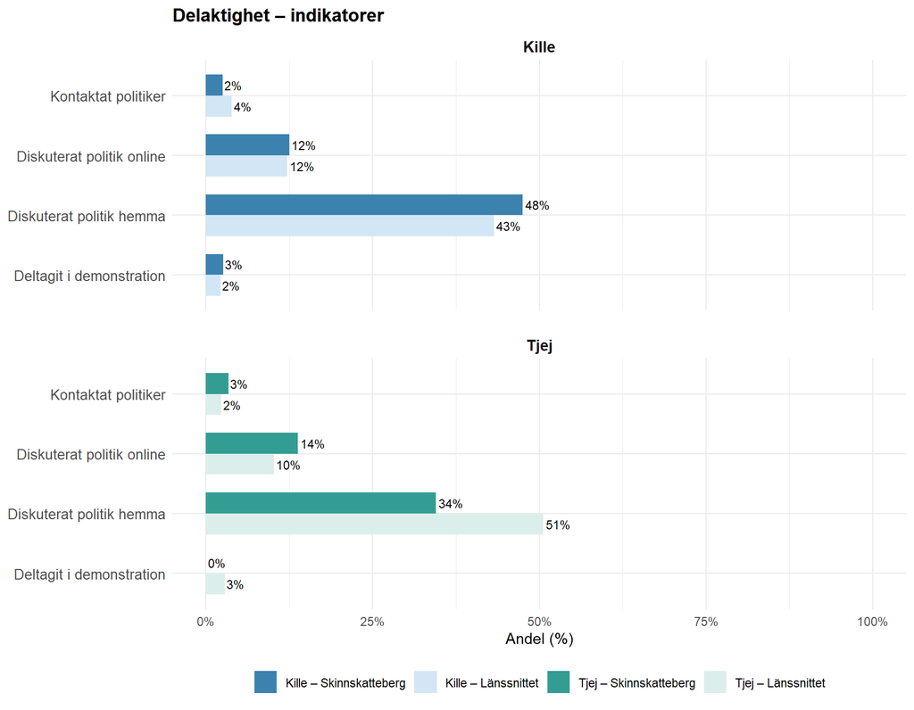

Diagram 11. Indikatatorer inom Delaktighet - andel per kön jämfört med länssnittet

Tabell 6. Indikatorer inom Delaktighet – kommunens värde jämfört med länssnittet.

| Indikator | Kommun (%) | Länssnittet (%) | ± % | Jämfört med länet |
| --- | --- | --- | --- | --- |
| Diskuterat politik hemma | 42 | 47 | -5 | ▼ Lägre |
| Diskuterat politik online | 13 | 11 | 2 | ▲ Högre |
| Deltagit i demonstration | 2 | 2 | -1 | ▼ Lägre |
| Kontaktat politiker | 3 | 3 | 0 | ▼ Lägre |

För området Delaktighet ligger Skinnskattebergs samlade resultat i linje med länets genomsnitt, men andelen som diskuterat politik hemma skiljer sig mellan tjejer och killar. Bland tjejer är andelen 17 procentenheter lägre än bland tjejer i länet, medan andelen bland killar är 5 procentenheter högre än i länet. Det innebär att killar i Skinnskatteberg oftare än tjejer diskuterar politik hemma, vilket är det omvända jämfört med länet. Övriga indikatorer ligger nära länets nivå för både tjejer och killar.

## Samhällssyn

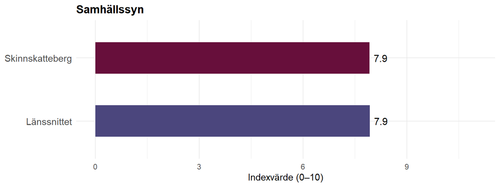

Diagram 12. Indexvärde för Samhällssyn jämfört med länssnittet.

Resultatet för Skinnskatteberg visar en nivå i linje med länsgenomsnittet på området Samhällssyn (7.9 jämfört med 7.9), vilket innebär att kommunen följer det övergripande mönstret i länet.

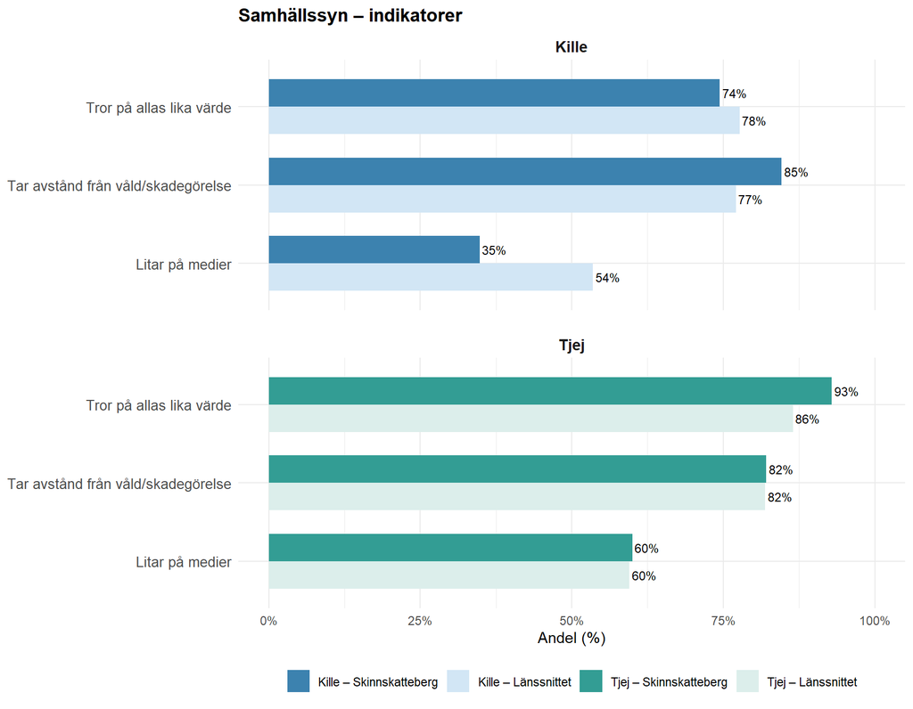

Diagram 13. Indikatorer inom Samhällssyn - andel per kön jämfört med länssnittet

Tabell 7. Indikatorer inom Samhällssyn – kommunens värde jämfört med länssnittet.

| Indikator | Kommun (%) | Länssnittet (%) | ± % | Jämfört med länet |
| --- | --- | --- | --- | --- |
| Litar på medier | 45 | 56 | -12 | ▼ Lägre |
| Tar avstånd från våld/skadegörelse | 84 | 80 | 4 | ▲ Högre |
| Tror på allas lika värde | 82 | 82 | 0 | ▼ Lägre |

Det övergripande resultatet för området Samhällssyn ligger på en liknande nivå som i länet, men på indikatornivå går resultaten åt olika håll. Andelen killar som litar på medier är 19 procentenheter lägre än bland killar i länet, medan andelen killar som tar avstånd från våld och skadegörelse är högre än i länet. Bland tjejer är andelen som tror på allas lika värde 7 procentenheter högre än i länet, och övriga indikatorer ligger i nivå med länet. Skillnaden mellan tjejer och killar i tillit till medier är därmed större i Skinnskatteberg än i länet.

## Trygghet

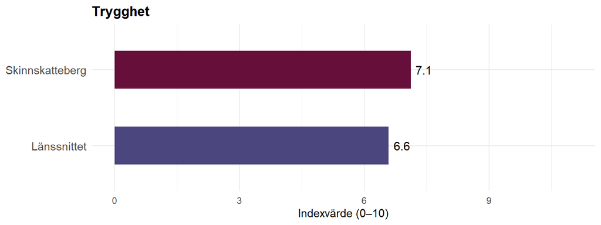

Diagram 14. Indexvärde för Trygghet jämfört med länssnittet.

Resultatet för Skinnskatteberg visar en mer gynnsam nivå på området Trygghet jämfört med länsgenomsnittet (7.1 jämfört med 6.6), vilket tyder på att kommunen överlag har mer gynnsamma utfall för de indikatorer som ingår i området.

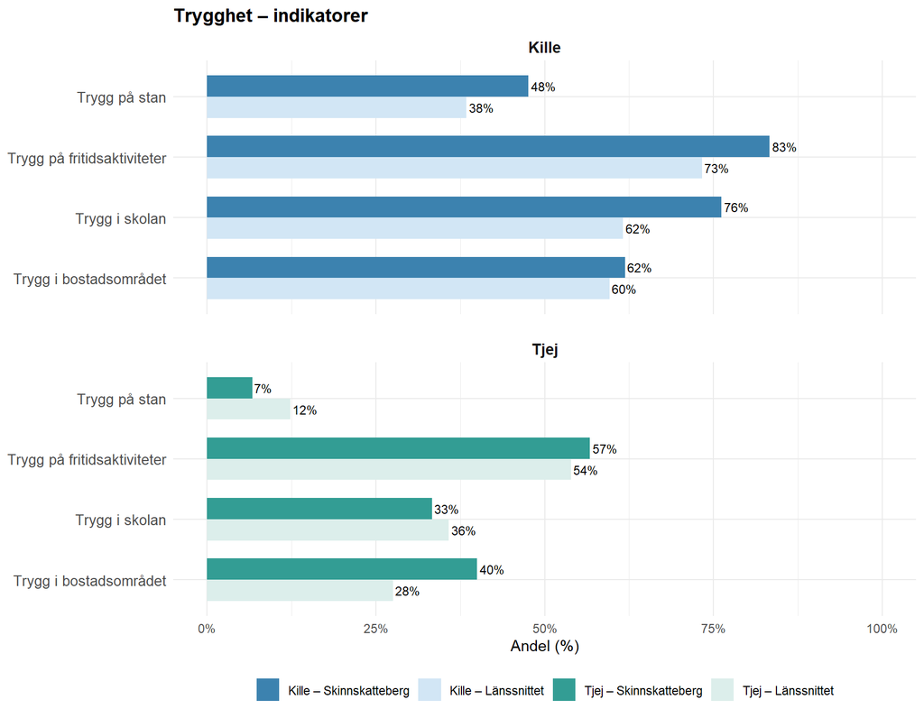

Diagram 15. Indikatorer inom Trygghet - andel per kön jämfört med länssnittet

Tabell 8. Indikatorer inom Trygghet – kommunens värde jämfört med länssnittet.

| Indikator | Kommun (%) | Länssnittet (%) | ± % | Jämfört med länet |
| --- | --- | --- | --- | --- |
| Trygg i skolan | 58 | 48 | 10 | ▲ Högre |
| Trygg i bostadsområdet | 53 | 43 | 10 | ▲ Högre |
| Trygg på fritidsaktiviteter | 72 | 63 | 9 | ▲ Högre |
| Trygg på stan | 31 | 25 | 5 | ▲ Högre |

Skinnskattebergs mer gynnsamma resultat för området Trygghet drivs i huvudsak av högre nivåer bland killar. Killar rapporterar i större utsträckning att de känner sig trygga i skolan, på stan och på fritidsaktiviteter, än killar i länet. Tydligast är skillnaden för trygghet i skolan, 14 procentenheter. Bland tjejer är bilden mer blandad. Andelen som uppger att de känner sig trygga i sitt bostadsområde är högre än i länet, medan trygghet i skolan och på stan är något lägre. Skillnaderna mellan tjejer och killar är överlag större i Skinnskatteberg än i länet, särskilt för trygghet i skolan och på stan.

## Fritid

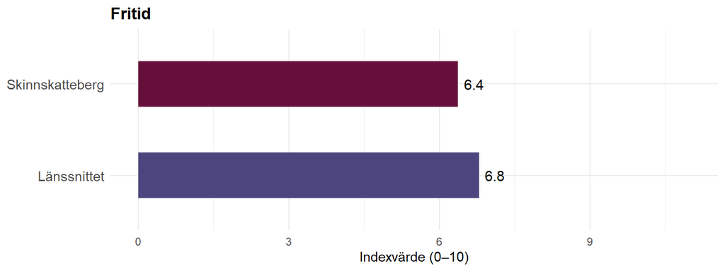

Diagram 16. Indexvärde för Fritid jämfört med länssnittet.

Resultatet för Skinnskatteberg visar en mindre gynnsam nivå på området Fritid jämfört med länsgenomsnittet (6.4 jämfört med 6.8), vilket tyder på att kommunen överlag har mindre gynnsamma utfall för de indikatorer som ingår i området.

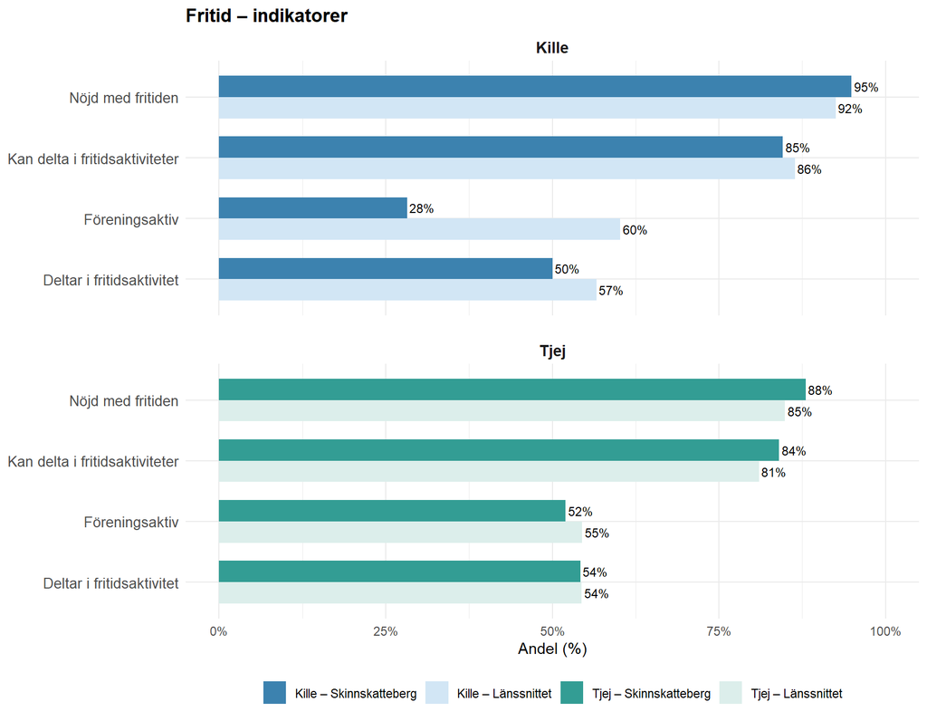

Diagram 17. Indikatorer inom Fritid - andel per kön jämfört med länssnittet

Tabell 9. Indikatorer inom Fritid – kommunens värde jämfört med länssnittet.

| Indikator | Kommun (%) | Länssnittet (%) | ± % | Jämfört med länet |
| --- | --- | --- | --- | --- |
| Föreningsaktiv | 38 | 57 | -20 | ▼ Lägre |
| Deltar i fritidsaktivitet | 52 | 56 | -4 | ▼ Lägre |
| Nöjd med fritiden | 92 | 89 | 4 | ▲ Högre |
| Kan delta i fritidsaktiviteter | 84 | 84 | 1 | ▲ Högre |

Skinnskattebergs mindre gynnsamma resultat för området Fritid drivs i huvudsak av en lägre andel föreningsaktiva killar. Bland killar är andelen som uppger att de är föreningsaktiva ungefär hälften så stor som i länet, en skillnad på 32 procentenheter. Även deltagandet i fritidsaktiviteter är något lägre bland killar. Bland tjejer ligger samtliga indikatorer nära länets nivå. Detsamma gäller killarnas nöjdhet med fritiden och möjlighet att delta i fritidsaktiviteter. Till skillnad från länet är föreningsaktivitet vanligare bland tjejer än bland killar i Skinnskatteberg.

## Levnadsvillkor

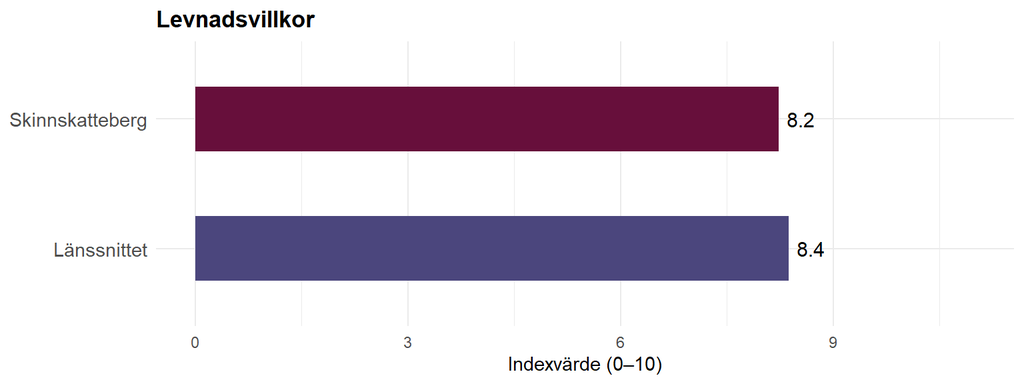

Diagram 18. Indexvärde för Levnadsvillkor jämfört med länssnittet.

Resultatet för Skinnskatteberg visar en nivå i linje med länsgenomsnittet på området Levnadsvillkor (8.2 jämfört med 8.4), vilket innebär att kommunen följer det övergripande mönstret i länet.

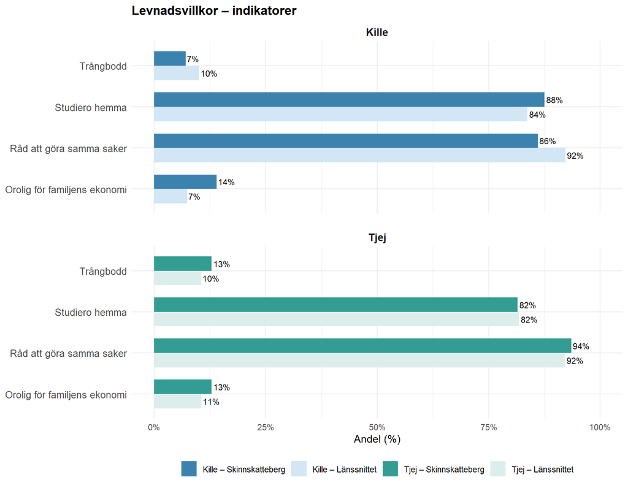

Diagram 19. Indikatorer inom Levnadsvillkor - andel per kön jämfört med länssnittet

Tabell 10. Indikatorer inom Levnadsvillkor – kommunens värde jämfört med länssnittet.

| Indikator | Kommun (%) | Länssnittet (%) | ± % | Jämfört med länet |
| --- | --- | --- | --- | --- |
| Orolig för familjens ekonomi | 14 | 9 | 4 | ▲ Högre |
| Råd att göra samma saker | 89 | 92 | -3 | ▼ Lägre |
| Studiero hemma | 85 | 83 | 2 | ▲ Högre |
| Trångbodd | 10 | 10 | -1 | ▼ Lägre |

Resultatet för området Levnadsvillkor ligger nära länets nivå, men bland killar framträder vissa skillnader. Andelen killar som uppger att de är oroliga för familjens ekonomi är dubbelt så stor som bland killar i länet, och andelen som anser att familjen har råd att göra samma saker som andra är något lägre. Bland tjejer ligger samtliga indikatorer nära länets nivå. Till skillnad från länet, där oro för familjens ekonomi är vanligare bland tjejer, rapporterar tjejer och killar i Skinnskatteberg ungefär samma nivå.

## Föräldrarelation

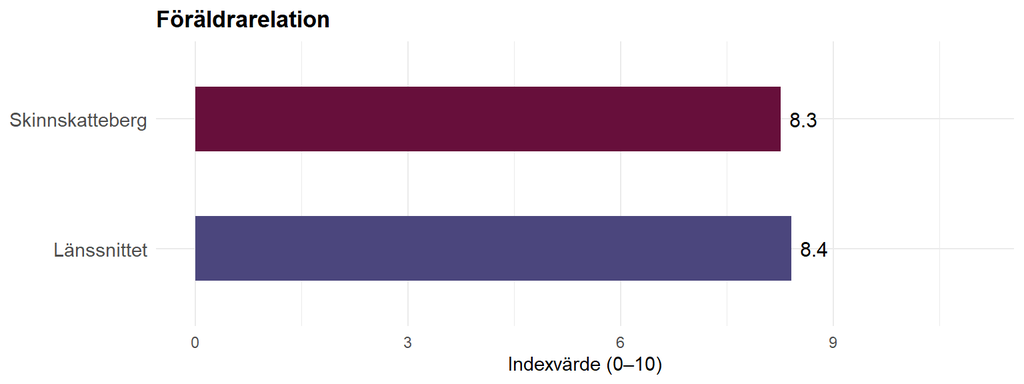

Diagram 20. Indexvärde för Föräldrarelation jämfört med länssnittet.

Resultatet för Skinnskatteberg visar en nivå i linje med länsgenomsnittet på området Föräldrarelation (8.3 jämfört med 8.4), vilket innebär att kommunen följer det övergripande mönstret i länet.

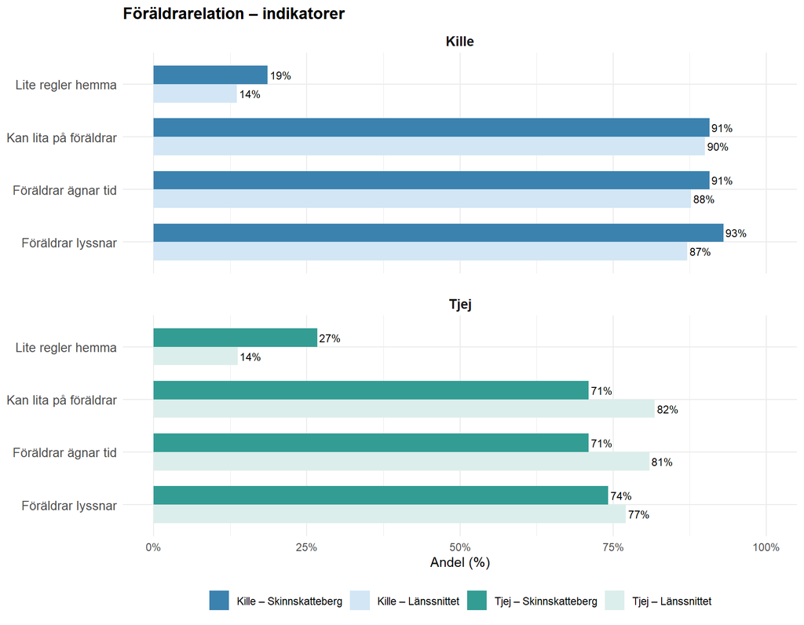

Diagram 21. Indikatorer inom Föräldrarelation - andel per kön jämfört med länssnittet

Tabell 11. Indikatorer inom Föräldrarelation – kommunens värde jämfört med länssnittet.

| Indikator | Kommun (%) | Länssnittet (%) | ± % | Jämfört med länet |
| --- | --- | --- | --- | --- |
| Lite regler hemma | 22 | 14 | 8 | ▲ Högre |
| Kan lita på föräldrar | 82 | 86 | -4 | ▼ Lägre |
| Föräldrar lyssnar | 85 | 82 | 3 | ▲ Högre |
| Föräldrar ägnar tid | 82 | 84 | -2 | ▼ Lägre |

På indikatornivå skiljer sig resultaten inom Föräldrarelation mellan tjejer och killar, trots att det samlade resultatet ligger nära länets. Andelen tjejer som uppger att de kan lita på sina föräldrar och att föräldrarna ägnar tid åt dem är omkring 10 procentenheter lägre än bland tjejer i länet. Samtidigt är andelen tjejer som rapporterar lite regler hemma nästan dubbelt så stor som i länet. Bland killar ligger resultaten överlag nära eller något över länets nivå, men även här är andelen med lite regler hemma något högre. Skillnaderna mellan tjejer och killar är därmed större i Skinnskatteberg än i länet.

## Studiegång och resultat

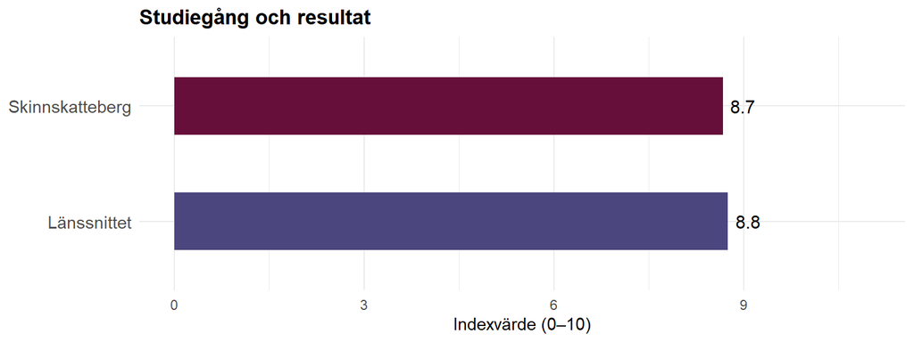

Diagram 22. Indexvärde för Studiegång och resultat jämfört med länssnittet.

Resultatet för Skinnskatteberg visar en nivå i linje med länsgenomsnittet på området Studiegång och resultat (8.7 jämfört med 8.8), vilket innebär att kommunen följer det övergripande mönstret i länet.

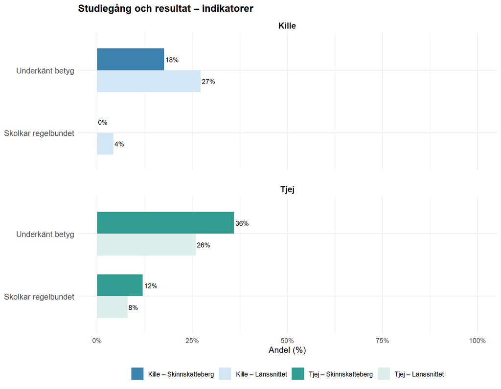

Diagram 23. Indikatorer inom Studiegång och resultat - andel per kön jämfört med länssnittet

Tabell 12. Indikatorer inom Studiegång och resultat – kommunens värde jämfört med länssnittet.

| Indikator | Kommun (%) | Länssnittet (%) | ± % | Jämfört med länet |
| --- | --- | --- | --- | --- |
| Underkänt betyg | 25 | 26 | -1 | ▼ Lägre |
| Skolkar regelbundet | 5 | 6 | -1 | ▼ Lägre |

Resultatet för området Studiegång och resultat är i nivå med länet, men bland tjejer och killar finns motsatta mönster. Bland tjejer är andelen som uppger underkänt betyg 10 procentenheter högre än bland tjejer i länet, och även regelbundet skolk är något vanligare. Bland killar är andelen med underkänt betyg i stället lägre än i länet, och ingen kille uppger att de skolkar regelbundet. I länet är andelen med underkänt betyg ungefär lika stor bland tjejer och killar, medan den i Skinnskatteberg är dubbelt så stor bland tjejer.

## Skolmiljö och stöd

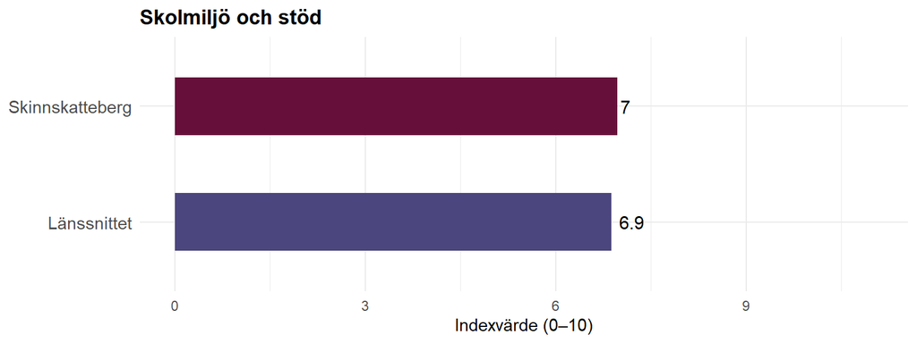

Diagram 24. Indexvärde för Skolmiljö och stöd jämfört med länssnittet.

Resultatet för Skinnskatteberg visar en nivå i linje med länsgenomsnittet på området Skolmiljö och stöd (7 jämfört med 6.9), vilket innebär att kommunen följer det övergripande mönstret i länet.

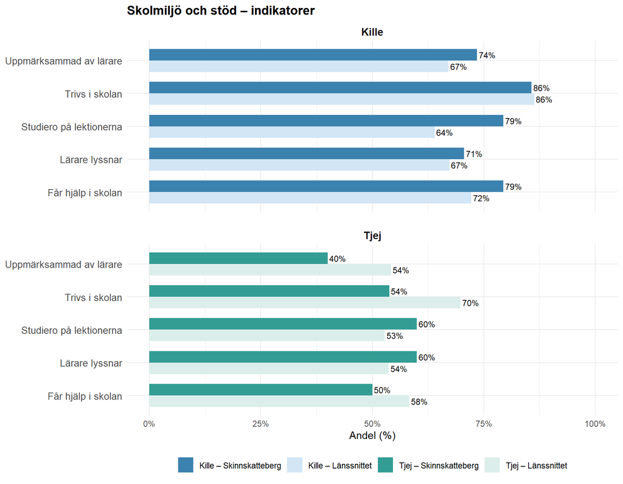

Diagram 25. Indikatorer inom Skolmiljö och stöd - andel per kön jämfört med länssnittet

Tabell 13. Indikatorer inom Skolmiljö och stöd – kommunens värde jämfört med länssnittet.

| Indikator | Kommun (%) | Länssnittet (%) | ± % | Jämfört med länet |
| --- | --- | --- | --- | --- |
| Studiero på lektionerna | 71 | 58 | 13 | ▲ Högre |
| Lärare lyssnar | 66 | 60 | 6 | ▲ Högre |
| Trivs i skolan | 72 | 78 | -6 | ▼ Lägre |
| Får hjälp i skolan | 67 | 65 | 2 | ▲ Högre |
| Uppmärksammad av lärare | 59 | 60 | -1 | ▼ Lägre |

Inom området Skolmiljö och stöd varierar resultaten mellan indikatorerna och mellan tjejer och killar. Studiero på lektionerna rapporteras i högre grad än i länet av både tjejer och killar, och tydligast är skillnaden bland killar (15 procentenheter). Bland tjejer är däremot andelen som trivs i skolan och känner sig uppmärksammade av lärare betydligt lägre än i länet, och även andelen som får hjälp i skolan är lägre. Killar rapporterar överlag nivåer i linje med eller något över länet på samtliga indikatorer. Skillnaderna mellan tjejer och killar är därmed mer uttalade i Skinnskatteberg än i länet, särskilt när det gäller trivsel och att bli uppmärksammad av lärare.

## Socialt stöd och ensamhet

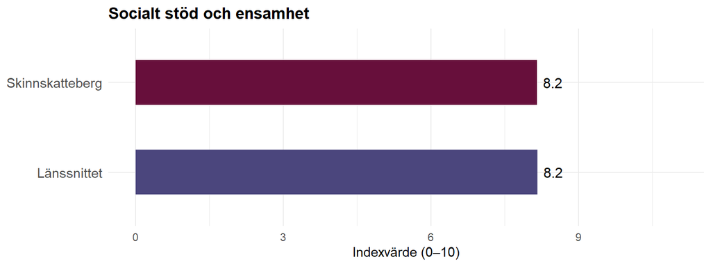

Diagram 26. Indexvärde för Socialt stöd och ensamhet jämfört med länssnittet.

Resultatet för Skinnskatteberg visar en nivå i linje med länsgenomsnittet på området Socialt stöd och ensamhet (8.2 jämfört med 8.2), vilket innebär att kommunen följer det övergripande mönstret i länet.

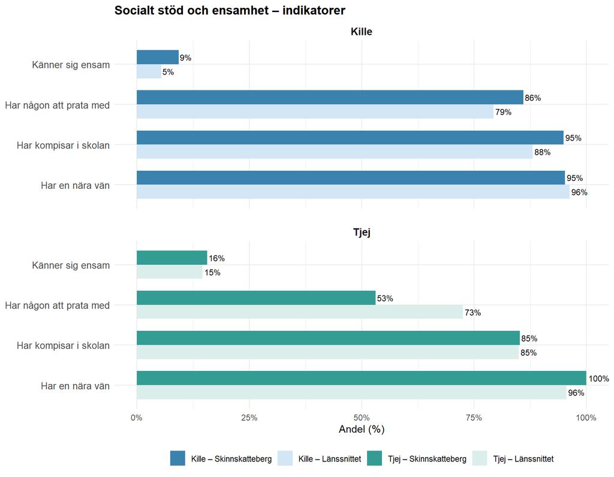

Diagram 27. Indikatorer inom Socialt stöd och ensamhet - andel per kön jämfört med länssnittet

Tabell 14. Indikatorer inom Socialt stöd och ensamhet – kommunens värde jämfört med länssnittet.

| Indikator | Kommun (%) | Länssnittet (%) | ± % | Jämfört med länet |
| --- | --- | --- | --- | --- |
| Har kompisar i skolan | 91 | 86 | 4 | ▲ Högre |
| Har någon att prata med | 72 | 76 | -4 | ▼ Lägre |
| Känner sig ensam | 12 | 10 | 2 | ▲ Högre |
| Har en nära vän | 97 | 96 | 1 | ▲ Högre |

Det övergripande resultatet för området Socialt stöd och ensamhet ligger på en liknande nivå som i länet, men andelen som uppger att de har någon att prata med skiljer sig mellan tjejer och killar. Bland tjejer är andelen som uppger att de har någon att prata med 20 procentenheter lägre än bland tjejer i länet. Killar rapporterar i stället något högre nivåer än länet både för att ha någon att prata med och för att ha kompisar i skolan. Andelen killar som känner sig ensamma är också något högre än i länet, men andelarna är låga. Skillnaden mellan tjejer och killar i att ha någon att prata med är därmed betydligt större i Skinnskatteberg än i länet.

## Livsstil

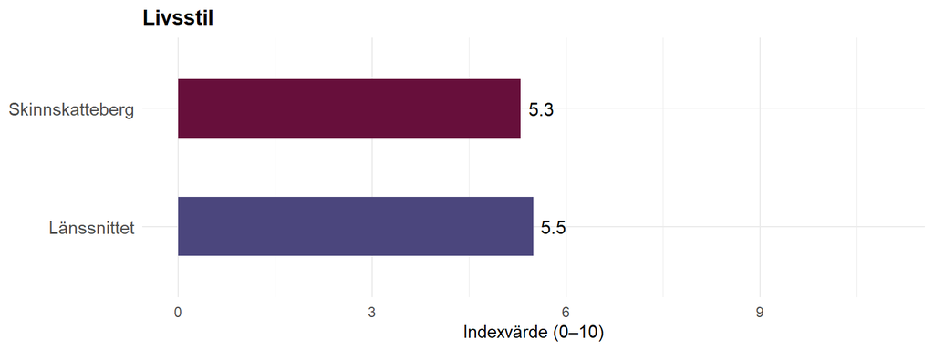

Diagram 29. Indexvärde för Livsstil jämfört med länssnittet.

Resultatet för Skinnskatteberg visar en nivå i linje med länsgenomsnittet på området Livsstil (5.3 jämfört med 5.5), vilket innebär att kommunen följer det övergripande mönstret i länet.

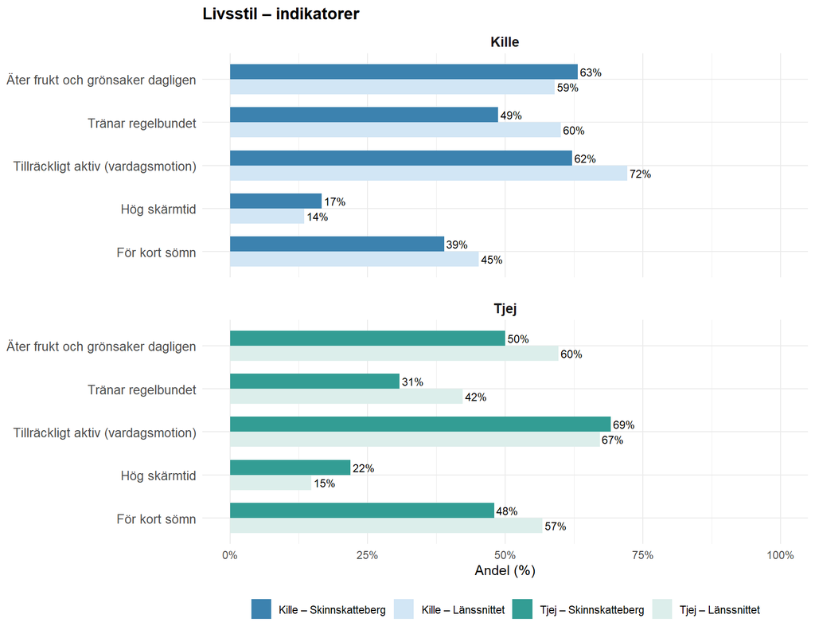

Diagram 30. Indikatorer inom Livsstil - andel per kön jämfört med länssnittet

Tabell 15. Indikatorer inom Livsstil – kommunens värde jämfört med länssnittet.

| Indikator | Kommun (%) | Länssnittet (%) | ± % | Jämfört med länet |
| --- | --- | --- | --- | --- |
| Tränar regelbundet | 42 | 51 | -9 | ▼ Lägre |
| För kort sömn | 43 | 51 | -9 | ▼ Lägre |
| Hög skärmtid | 19 | 14 | 5 | ▲ Högre |
| Tillräckligt aktiv (vardagsmotion) | 65 | 70 | -4 | ▼ Lägre |
| Äter frukt och grönsaker dagligen | 58 | 59 | -2 | ▼ Lägre |

Skinnskattebergs resultat för området Livsstil ligger nära länets, men på indikatornivå går resultaten åt olika håll. Andelen som tränar regelbundet är lägre än i länet bland både tjejer och killar, med en skillnad på omkring 11 procentenheter för respektive kön. Bland tjejer är också andelen som äter frukt och grönsaker dagligen lägre, medan hög skärmtid är vanligare än bland tjejer i länet. Bland killar är andelen som är tillräckligt fysiskt aktiva i vardagen lägre än i länet. Samtidigt är andelen som uppger för kort sömn lägre än i länet bland både tjejer och killar.